# Daily Overview

Author

Yan Zhu

Published

June 1, 2024

## Introduction

1. Understand the structure of the daily data.
2. Divide the different question sets.
- ALCOHOL USE
- PARTNERED SEXUAL BEHAVIOR (PSB) & CONDOM USE BEHAVIOR (CUB)
- ONLINE SEXUAL BEHAVIOR (OSB)
- SOLO SEXUAL BEHAVIOR (SSB)
- DRUG USE BEHAVIOR (DUB)
- GENERAL MENTAL HEALTH BLOCK
3. Analysis all of 6 question sets.

## Set Up

```r
# options(conflicts.policy = "depends.ok")
source("/Users/yan/Desktop/sample_code/functions.R")

library(tidyverse)
library(janitor)
library(skimr)
library(psych)
library(knitr)
library(ggplot2)
library(car)
```

```r
daily <- read_csv("/Users/yan/Desktop/sample_code/ESM/1_anonymization/anonymous_daily.csv") %>% clean_names()
```

## General Information

```r
daily <- daily[daily$progress == 100, ]
cat("We have", nrow(daily), "completed survey records, and there are", length(unique(daily$random_id)), "participants.")
```

```
We have 5912 completed survey records, and there are 254 participants.
```

**Question:** How many survey records for each participant.

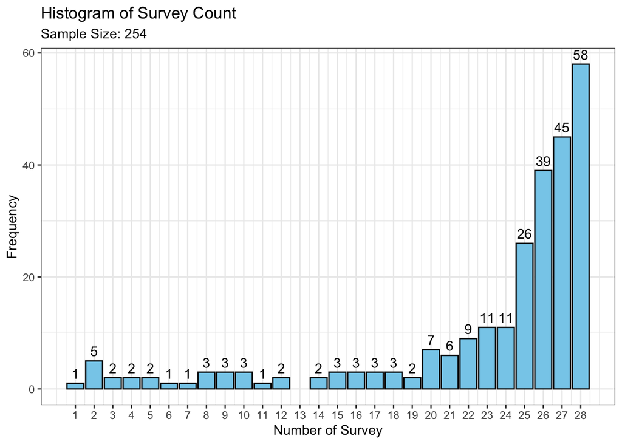

```r
# count number of survey for each participants.
each_id <- daily %>%
  group_by(random_id) %>%
  summarize(num_survey = n())

# Histogram
ggplot(each_id, aes(x = num_survey)) +
  geom_bar(fill = "skyblue", color = "black") +
  geom_text(stat = "count", aes(label = after_stat(count)), vjust = -0.5) +
  scale_x_continuous(breaks = seq(min(each_id$num_survey), max(each_id$num_survey), by = 1)) +
  labs(x = "Number of Survey",
       y = "Frequency",
       title = "Histogram of Survey Count",
       subtitle = paste("Sample Size:", nrow(each_id))) +
  theme(plot.subtitle = element_text(size = 10)) +
  theme_bw()
```

## Divide

### Alcohol use

Since the last survey, have you had 1 or more alcoholic drinks? A standard drink is a 12 oz beer, a 8-9 oz of malt liquor, a 5 oz glass of wine, or a 1.5 ounce shot

```r
prop_tab(daily, aub1) # Yes = 1, No = 0, Prefer not to respond = 3
```

```
# A tibble: 3 × 3
   aub1     n    prop
  <dbl> <int>   <dbl>
1     0  4797 0.811
2     1  1085 0.184
3     3    30 0.00507
```

```r
alcohol_use <- daily[daily$aub1 == 1, ]

alcohol_use <- alcohol_use %>% select(random_id, id_day, recorded_date, status, progress,
                                      duration_in_seconds, au_t, au_v, au_l, au_loc_txt,
                                      au_pbs, au_pbs_txt, au_pg, au_dg, au_bib, au_fib, au_drg)
```

### Partnered sexual behavior

Since the last survey, have you hooked up, engaged in any sexual activity, or tried to engage in any sexual activity with another person (including flirting, kissing, touching, or intercourse)?

```r
prop_tab(daily, psb1) # Yes = 1, No = 0, Prefer not to respond = 3
```

```
# A tibble: 3 × 3
   psb1     n    prop
  <dbl> <int>   <dbl>
1     0  5384 0.911
2     1   499 0.0844
3     3    29 0.00491
```

```r
ps_behavior <- daily[daily$psb1 == 1, ]

ps_behavior <- ps_behavior %>% select(
  random_id, id_day, recorded_date, status, progress, duration_in_seconds,
  psb2, cub1, cub2, cub3, cub4, cub5, cub6, psb3, psb4, psb5, psb5a, psb6, psb6a,
  str_p, str_p_txt, psb7, psb8, psb9, psb7a, psb8a, psb9a, psb10, psb10a, psb11, psb11a,
  med1_p, med2_p, med3_p, med4_p, aro_pf, pls_pf, con_pf, ver_pc, enon_pc, inon_pc,
  prp_v, prp_p, prp_sf, prp_in, vic_v, vic_p, vic_sf, vic_in, exp_p, st_p,
  pa1_p, na1_p, na2_p, na3_p, na4_p, na5_p, pa2_p, er1_p, er2_p, er3_p, er4_p)
```

### Online sexual behavior

Since the last survey, have you used any websites, dating apps, or social platforms to look for sexual imagery, partners, or content?

```r
prop_tab(daily, osb1) # Yes = 1, No = 0, Prefer not to respond = 3
```

```
# A tibble: 3 × 3
   osb1     n    prop
  <dbl> <int>   <dbl>
1     0  5677 0.960
2     1   199 0.0337
3     3    36 0.00609
```

```r
os_behavior <- daily[daily$osb1 == 1, ]

os_behavior <- os_behavior %>%
  select(
    random_id, id_day, recorded_date, status, progress, duration_in_seconds,
    osb2, osb2_txt, osb3, osb4, osb5, osb6, osb6_txt, osb7, osb8,
    osb9, osb10, aro_of, pls_of, pss, exp_o, str_o, pa1_o,
    na1_o, na2_o, na3_o, na4_o, pa2_o, na5_o,
    er1_o, er2_o, er3_o, er4_o)
```

### Solo sexual activity

Since the last survey, have you engaged in any solo sexual activity (i.e., masturbation)?

```r
prop_tab(daily, ssb1) # Yes = 1, No = 0, Prefer not to respond = 3
```

```
# A tibble: 3 × 3
   ssb1     n    prop
  <dbl> <int>   <dbl>
1     0  5377 0.910
2     1   484 0.0819
3     3    51 0.00863
```

```r
ss_behavior <- daily[daily$ssb1 == 1, ]

ss_behavior <- ss_behavior %>%
  select(
    random_id, id_day, recorded_date, status, progress, duration_in_seconds,
    ssb2, ssb3, ssb3_txt, ssb4, ssb5, ssb6,
    aro_sf, pls_sf, exp_s, str_s, pa1_s, na1_s, na2_s, na3_s,
    na4_s, na5_s, pa2_s, er1_s, er2_s, er3_s, er4_s)
```

### Drug use

Since the last survey, have you used any recreational drugs (e.g., marijuana, cocaine) or prescription medications?

```r
prop_tab(daily, dub1) # Yes = 1, No = 0, Prefer not to respond = 3
```

```
# A tibble: 3 × 3
   dub1     n    prop
  <dbl> <int>   <dbl>
1     0  5314 0.899
2     1   563 0.0952
3    NA    35 0.00592
```

*There are NA because they had said “No” or “Prefer not to respond” to most of the questions above.*

```r
daily[is.na(daily$dub1),] %>%
  select(aub1, psb1, osb1, ssb1)
```

```
# A tibble: 35 × 4
    aub1  psb1  osb1  ssb1
   <dbl> <dbl> <dbl> <dbl>
 1     1     0     0     0
 2     0     0     3     3
 3     3     3     3     3
 4     3     3     3     3
 5     0     0     0     0
 6     0     0     0     0
 7     1     0     0     0
 8     0     0     0     0
 9     0     0     0     0
10     3     3     3     3
# ℹ 25 more rows
```

```r
drug_use <- daily[daily$dub1 == 1, ]

drug_use <- drug_use %>%
  select(
    random_id, id_day, recorded_date, status, progress, duration_in_seconds,
    dub2, dub2_txt,
    med1_d, med2_d, med3_d, med4_d,
    exp_d, str_d, dub3_bf, dub3_bf_txt, dub3_du, dub3_du_txt, dub3_af, dub3_af_txt,
    dub4, dub5, dub6
    )
```

### Drinking contexts

```r
prop_tab(daily, bpa)
```

```
# A tibble: 3 × 3
    bpa     n    prop
  <dbl> <int>   <dbl>
1     0  5135 0.869
2     1   743 0.126
3    NA    34 0.00575
```

*NA in “bpa” (bar and party attendance) because they thought it was “Not applicable” to them (i.e., I did not drink, so I do not need to answer this question about where people drink).*

### Pornography

Since the last survey, have you viewed any pornographic material?

```r
prop_tab(daily, pub1) # Yes = 1, No = 0, Prefer not to respond = 3
```

```
# A tibble: 3 × 3
   pub1     n    prop
  <dbl> <int>   <dbl>
1     0  5521 0.934
2     1   357 0.0604
3     3    34 0.00575
```

### General Mental Health Block

Let’s check the proportion of answered General Mental Health Block

```r
# Define the list of columns
general_mh_list <- c("imp1", "imp2", "imp3", "imp4",
                     "dep1", "dep2", "insom", "fatig",
                     "anx1", "anx2",
                     "traum1", "traum2", "traum3", "traum4")

# Create the new column "general_mh"
daily <- daily %>%
  mutate(general_mh = if_else(rowSums(!is.na(select(., all_of(general_mh_list)))) > 0, 1, 0))

prop_tab(daily, general_mh)
```

```
# A tibble: 2 × 3
  general_mh     n   prop
       <dbl> <int>  <dbl>
1          0   419 0.0709
2          1  5493 0.929
```

```r
general_mh <- daily[daily$general_mh == 1, ]

general_mh <- general_mh %>%
  select(random_id, id_day, day, recorded_date, status, progress, duration_in_seconds,
         imp1, imp2, imp3, imp4,
         dep1, dep2, insom, fatig,
         anx1, anx2,
         traum1, traum2, traum3, traum4)
```

**Sum Scores MH**

```r
# Very slightly or not at all = 1; A little = 2; Moderately = 3; Quite a bit = 4; Extremely = 5
general_mh$imp_sum <- general_mh$imp1 + general_mh$imp2 + general_mh$imp3 + general_mh$imp4

# 0 = Not at all; 1 = Somewhat; 2 = Quite a bit; 3 = Entirely
general_mh$dep_sum <- general_mh$dep1 + general_mh$dep2

# 0 = Not at all; 1 = Somewhat; 2 = Quite a bit; 3 = Entirely
general_mh$anx_sum <- general_mh$anx1 + general_mh$anx2

# 0 = Not at all; 1 = A little bit; 2 = Moderately; 3 = Quite a bit; 4 = Extremely; 5 = Not applicable--I have never had a very stressful or traumatic experience
general_mh$traum_sum <- general_mh$traum1 + general_mh$traum2 + general_mh$traum3 + general_mh$traum4

skim(general_mh)
```

Data summary

| Name | general_mh |
| --- | --- |
| Number of rows | 5493 |
| Number of columns | 25 |
| _______________________ |  |
| Column type frequency: |  |
| character | 1 |
| numeric | 23 |
| POSIXct | 1 |
| ________________________ |  |
| Group variables | None |

**Variable type: character**

| skim_variable | n_missing | complete_rate | min | max | empty | n_unique | whitespace |
| --- | --- | --- | --- | --- | --- | --- | --- |
| id_day | 0 | 1 | 8 | 9 | 0 | 5493 | 0 |

**Variable type: numeric**

| skim_variable | n_missing | complete_rate | mean | sd | p0 | p25 | p50 | p75 | p100 | hist |
| --- | --- | --- | --- | --- | --- | --- | --- | --- | --- | --- |
| random_id | 0 | 1 | 539317.35 | 256596.24 | 102743 | 320567 | 534293 | 731216 | 998678 | ▇▇▇▇▇ |
| day | 0 | 1 | 14.24 | 8.04 | 1 | 7 | 14 | 21 | 28 | ▇▆▇▆▇ |
| status | 0 | 1 | 0.01 | 0.32 | 0 | 0 | 0 | 0 | 8 | ▇▁▁▁▁ |
| progress | 0 | 1 | 100.00 | 0.00 | 100 | 100 | 100 | 100 | 100 | ▁▁▇▁▁ |
| duration_in_seconds | 0 | 1 | 214.27 | 1911.66 | 22 | 39 | 56 | 99 | 71665 | ▇▁▁▁▁ |
| imp1 | 0 | 1 | 1.36 | 0.72 | 1 | 1 | 1 | 1 | 5 | ▇▂▁▁▁ |
| imp2 | 0 | 1 | 1.40 | 0.79 | 1 | 1 | 1 | 2 | 5 | ▇▂▁▁▁ |
| imp3 | 1 | 1 | 1.54 | 0.88 | 1 | 1 | 1 | 2 | 5 | ▇▂▁▁▁ |
| imp4 | 1 | 1 | 1.37 | 0.78 | 1 | 1 | 1 | 1 | 5 | ▇▂▁▁▁ |
| dep1 | 1 | 1 | 0.43 | 0.70 | 0 | 0 | 0 | 1 | 3 | ▇▃▁▁▁ |
| dep2 | 1 | 1 | 0.49 | 0.76 | 0 | 0 | 0 | 1 | 3 | ▇▃▁▁▁ |
| insom | 1 | 1 | 0.61 | 0.87 | 0 | 0 | 0 | 1 | 3 | ▇▃▁▂▁ |
| fatig | 2 | 1 | 0.78 | 0.91 | 0 | 0 | 1 | 1 | 3 | ▇▅▁▂▁ |
| anx1 | 1 | 1 | 0.65 | 0.84 | 0 | 0 | 0 | 1 | 3 | ▇▅▁▂▁ |
| anx2 | 1 | 1 | 0.52 | 0.82 | 0 | 0 | 0 | 1 | 3 | ▇▃▁▁▁ |
| traum1 | 11 | 1 | 1.85 | 2.32 | 0 | 0 | 0 | 5 | 5 | ▇▁▁▁▅ |
| traum2 | 13 | 1 | 1.85 | 2.32 | 0 | 0 | 0 | 5 | 5 | ▇▁▁▁▅ |
| traum3 | 12 | 1 | 1.88 | 2.29 | 0 | 0 | 0 | 5 | 5 | ▇▁▁▁▅ |
| traum4 | 14 | 1 | 1.82 | 2.32 | 0 | 0 | 0 | 5 | 5 | ▇▁▁▁▅ |
| imp_sum | 2 | 1 | 5.67 | 2.53 | 4 | 4 | 4 | 7 | 20 | ▇▁▁▁▁ |
| dep_sum | 1 | 1 | 0.92 | 1.37 | 0 | 0 | 0 | 2 | 6 | ▇▂▁▁▁ |
| anx_sum | 1 | 1 | 1.17 | 1.59 | 0 | 0 | 0 | 2 | 6 | ▇▂▁▁▁ |
| traum_sum | 15 | 1 | 7.41 | 9.13 | 0 | 0 | 1 | 20 | 20 | ▇▁▁▁▅ |

**Variable type: POSIXct**

| skim_variable | n_missing | complete_rate | min | max | median | n_unique |
| --- | --- | --- | --- | --- | --- | --- |
| recorded_date | 0 | 1 | 2022-10-19 11:41:12 | 2022-12-04 17:52:52 | 2022-11-07 11:30:23 | 5469 |

Calculate the number of each behavior and general mental health check count for each participant.

```r
# Count number of different type of survey were taken for each participant.

# Create a new data frame to store the counts for each random_id
type_counts <- daily %>%
  group_by(random_id) %>%
  summarize(
    aub1_count = sum(aub1 == 1),
    psb1_count = sum(psb1 == 1),
    osb1_count = sum(osb1 == 1),
    ssb1_count = sum(ssb1 == 1),
    dub1_count = sum(dub1 == 1),
    bpa_count = sum(bpa == 1),
    pub1_count = sum(pub1 == 1),
    general_mh_count = sum(general_mh == 1)
  )

# Merge data frame
each_id <- merge(each_id, type_counts, by = "random_id", all.x = TRUE)

# then I can delete type_counts to make my work place clean.
rm(type_counts)

head(each_id, 6)
```

```
  random_id num_survey aub1_count psb1_count osb1_count ssb1_count dub1_count
1    102743         18          5          2          1          5          1
2    110986         24          2          0          0          0          0
3    111019         23          3          1          0          0          0
4    111620         28          6          0          0          0          1
5    115640         28          4          0          2          5          6
6    117836         27          5          5          1          1         11
  bpa_count pub1_count general_mh_count
1         3          1               17
2         0          0               24
3         4          0               22
4         3          0               28
5         4          4               28
6         3          1               22
```

## 28 Surveys

Let’s focus on participant with fully 28 General Mental Health Block survey.

```r
survey_28 <- each_id[each_id$general_mh_count == 28, ]

daily_28 <- daily[daily$random_id %in% survey_28$random_id, ]

daily_28 <- daily_28 %>%
  select(id_day, aub1, psb1, osb1, ssb1, dub1, bpa, pub1)

daily_28$aub1 <- ifelse(daily_28$aub1 == 0, -0.5, 0.5) # -.5 == NO; 0.5 == YES
daily_28$psb1 <- ifelse(daily_28$psb1 == 0, -0.5, 0.5)
daily_28$osb1 <- ifelse(daily_28$osb1 == 0, -0.5, 0.5)
daily_28$ssb1 <- ifelse(daily_28$ssb1 == 0, -0.5, 0.5)
daily_28$dub1 <- ifelse(daily_28$dub1 == 0, -0.5, 0.5)
daily_28$bpa <- ifelse(daily_28$bpa == 0, -0.5, 0.5)
daily_28$pub1 <- ifelse(daily_28$pub1 == 0, -0.5, 0.5)

mh_28 <- general_mh[general_mh$random_id %in% survey_28$random_id, ]


survey_28 <- merge(mh_28, daily_28, by = "id_day")

skim(survey_28)
```

Data summary

| Name | survey_28 |
| --- | --- |
| Number of rows | 924 |
| Number of columns | 32 |
| _______________________ |  |
| Column type frequency: |  |
| character | 1 |
| numeric | 30 |
| POSIXct | 1 |
| ________________________ |  |
| Group variables | None |

**Variable type: character**

| skim_variable | n_missing | complete_rate | min | max | empty | n_unique | whitespace |
| --- | --- | --- | --- | --- | --- | --- | --- |
| id_day | 0 | 1 | 8 | 9 | 0 | 924 | 0 |

**Variable type: numeric**

| skim_variable | n_missing | complete_rate | mean | sd | p0 | p25 | p50 | p75 | p100 | hist |
| --- | --- | --- | --- | --- | --- | --- | --- | --- | --- | --- |
| random_id | 0 | 1 | 567845.21 | 222119.34 | 111620.0 | 406934.00 | 551194.0 | 701328.00 | 976638.0 | ▂▇▇▇▅ |
| day | 0 | 1 | 14.50 | 8.08 | 1.0 | 7.75 | 14.5 | 21.25 | 28.0 | ▇▇▇▇▇ |
| status | 0 | 1 | 0.00 | 0.00 | 0.0 | 0.00 | 0.0 | 0.00 | 0.0 | ▁▁▇▁▁ |
| progress | 0 | 1 | 100.00 | 0.00 | 100.0 | 100.00 | 100.0 | 100.00 | 100.0 | ▁▁▇▁▁ |
| duration_in_seconds | 0 | 1 | 114.22 | 524.84 | 22.0 | 37.00 | 50.0 | 82.00 | 10560.0 | ▇▁▁▁▁ |
| imp1 | 0 | 1 | 1.20 | 0.52 | 1.0 | 1.00 | 1.0 | 1.00 | 5.0 | ▇▁▁▁▁ |
| imp2 | 0 | 1 | 1.27 | 0.62 | 1.0 | 1.00 | 1.0 | 1.00 | 5.0 | ▇▁▁▁▁ |
| imp3 | 0 | 1 | 1.41 | 0.73 | 1.0 | 1.00 | 1.0 | 2.00 | 5.0 | ▇▂▁▁▁ |
| imp4 | 0 | 1 | 1.27 | 0.68 | 1.0 | 1.00 | 1.0 | 1.00 | 5.0 | ▇▁▁▁▁ |
| dep1 | 0 | 1 | 0.30 | 0.56 | 0.0 | 0.00 | 0.0 | 1.00 | 3.0 | ▇▂▁▁▁ |
| dep2 | 0 | 1 | 0.33 | 0.59 | 0.0 | 0.00 | 0.0 | 1.00 | 3.0 | ▇▃▁▁▁ |
| insom | 0 | 1 | 0.47 | 0.74 | 0.0 | 0.00 | 0.0 | 1.00 | 3.0 | ▇▃▁▁▁ |
| fatig | 1 | 1 | 0.63 | 0.75 | 0.0 | 0.00 | 0.0 | 1.00 | 3.0 | ▇▆▁▂▁ |
| anx1 | 0 | 1 | 0.45 | 0.65 | 0.0 | 0.00 | 0.0 | 1.00 | 3.0 | ▇▃▁▁▁ |
| anx2 | 0 | 1 | 0.38 | 0.61 | 0.0 | 0.00 | 0.0 | 1.00 | 3.0 | ▇▃▁▁▁ |
| traum1 | 0 | 1 | 1.41 | 2.18 | 0.0 | 0.00 | 0.0 | 5.00 | 5.0 | ▇▁▁▁▃ |
| traum2 | 0 | 1 | 1.41 | 2.19 | 0.0 | 0.00 | 0.0 | 5.00 | 5.0 | ▇▁▁▁▃ |
| traum3 | 0 | 1 | 1.37 | 2.11 | 0.0 | 0.00 | 0.0 | 2.25 | 5.0 | ▇▁▁▁▃ |
| traum4 | 1 | 1 | 1.33 | 2.15 | 0.0 | 0.00 | 0.0 | 5.00 | 5.0 | ▇▁▁▁▃ |
| imp_sum | 0 | 1 | 5.15 | 1.98 | 4.0 | 4.00 | 4.0 | 6.00 | 14.0 | ▇▁▁▁▁ |
| dep_sum | 0 | 1 | 0.64 | 1.05 | 0.0 | 0.00 | 0.0 | 1.00 | 6.0 | ▇▂▁▁▁ |
| anx_sum | 0 | 1 | 0.83 | 1.19 | 0.0 | 0.00 | 0.0 | 2.00 | 6.0 | ▇▂▁▁▁ |
| traum_sum | 1 | 1 | 5.51 | 8.51 | 0.0 | 0.00 | 0.0 | 15.00 | 20.0 | ▇▁▁▁▃ |
| aub1 | 0 | 1 | -0.40 | 0.30 | -0.5 | -0.50 | -0.5 | -0.50 | 0.5 | ▇▁▁▁▁ |
| psb1 | 0 | 1 | -0.48 | 0.14 | -0.5 | -0.50 | -0.5 | -0.50 | 0.5 | ▇▁▁▁▁ |
| osb1 | 0 | 1 | -0.49 | 0.09 | -0.5 | -0.50 | -0.5 | -0.50 | 0.5 | ▇▁▁▁▁ |
| ssb1 | 0 | 1 | -0.48 | 0.15 | -0.5 | -0.50 | -0.5 | -0.50 | 0.5 | ▇▁▁▁▁ |
| dub1 | 1 | 1 | -0.44 | 0.24 | -0.5 | -0.50 | -0.5 | -0.50 | 0.5 | ▇▁▁▁▁ |
| bpa | 0 | 1 | -0.43 | 0.25 | -0.5 | -0.50 | -0.5 | -0.50 | 0.5 | ▇▁▁▁▁ |
| pub1 | 0 | 1 | -0.49 | 0.10 | -0.5 | -0.50 | -0.5 | -0.50 | 0.5 | ▇▁▁▁▁ |

**Variable type: POSIXct**

| skim_variable | n_missing | complete_rate | min | max | median | n_unique |
| --- | --- | --- | --- | --- | --- | --- |
| recorded_date | 0 | 1 | 2022-10-20 10:10:01 | 2022-12-04 14:51:25 | 2022-11-09 10:51:13 | 923 |

### Impulsivity

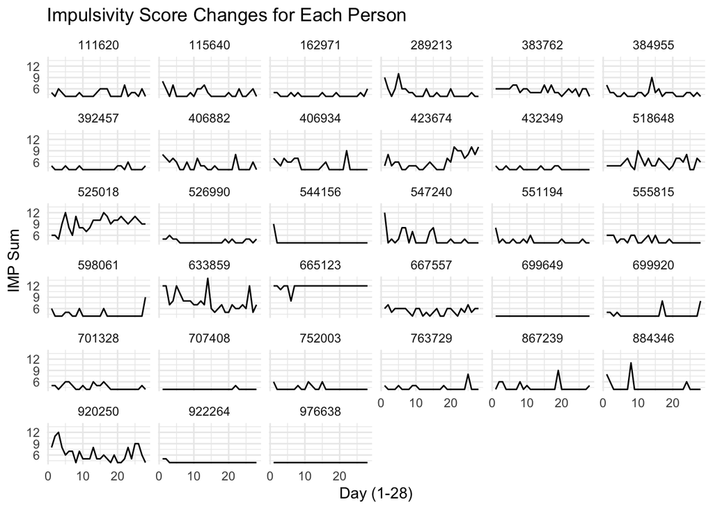

```r
# Create the line plots for each person
ggplot(survey_28, aes(x = day, y = imp_sum, group = random_id)) +
  geom_line() +
  labs(x = "Day (1-28)", y = "IMP Sum", color = "Random ID") +
  theme_minimal() +
  facet_wrap(~ random_id, scales = "fixed") +
  ggtitle("Impulsivity Score Changes for Each Person")
```

```r
model <- lmer(imp_sum ~ osb1 * bpa + (1 + day | random_id), data = survey_28)
```

```
fixed-effect model matrix is rank deficient so dropping 1 column / coefficient
```

```r
summary(model)
Anova(model, type = 3, test = "F")
```

- aub1_Alcohol use
- psb1_Partnered sexual behavior
- osb1_Online sexual behavior: b=1.02, F(1,873.1)=5.51, p=0.01916 *
- ssb1_Solo sexual activity
- dub1_Drug use
- bpa_Drinking contexts: b=0.46, F(1,878.17)=8.80, p=0.0031 **
- pub1_Pornography

### Depression symptoms: Anhedonia + Mood

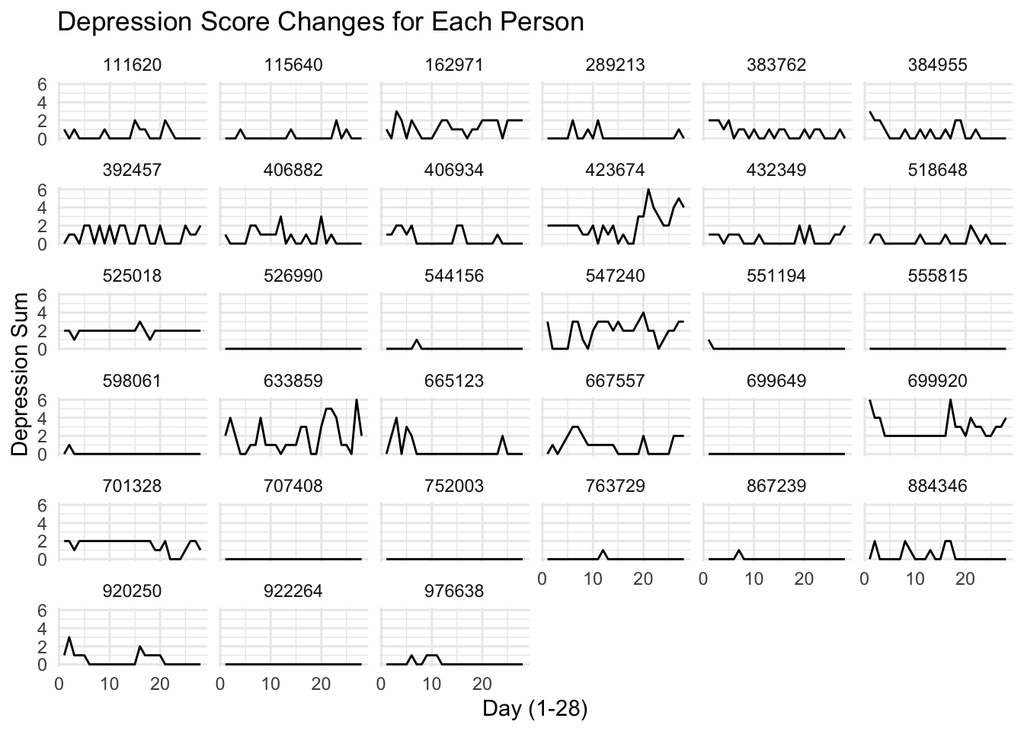

```r
# Create the line plots for each person
ggplot(survey_28, aes(x = day, y = dep_sum, group = random_id)) +
  geom_line() +
  labs(x = "Day (1-28)", y = "Depression Sum", color = "Random ID") +
  theme_minimal() +
  facet_wrap(~ random_id, scales = "fixed") +
  ggtitle("Depression Score Changes for Each Person")
```

```r
model <- lmer(dep_sum ~ aub1 * bpa + (1 + day | random_id), data = survey_28)
summary(model)
Anova(model, type = 3, test = "F")
```

- aub1_Alcohol us: b=-0.27, F(1,893.62)=10.39, p=0.001317 **
- psb1_Partnered sexual behavior
- osb1_Online sexual behavior
- ssb1_Solo sexual activity
- dub1_Drug use
- bpa_Drinking contexts: b=-0.21, F(1,893.29)=4.36, 0.03717 *
- pub1_Pornography

### Sleep difficulties

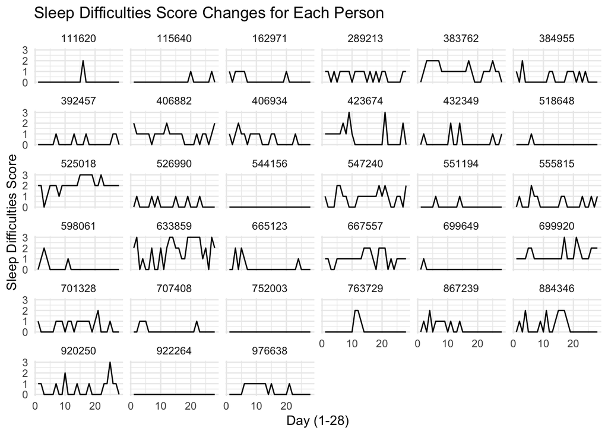

```r
# Create the line plots for each person
ggplot(survey_28, aes(x = day, y = insom, group = random_id)) +
  geom_line() +
  labs(x = "Day (1-28)", y = "Sleep Difficulties Score", color = "Random ID") +
  theme_minimal() +
  facet_wrap(~ random_id, scales = "fixed") +
  ggtitle("Sleep Difficulties Score Changes for Each Person")
```

```r
model <- lmer(insom ~ aub1 * bpa + (1 + day | random_id), data = survey_28)
summary(model)
Anova(model, type = 3, test = "F")
```

- aub1_Alcohol use: b=-0.19, F(1,896.84)=9.36, p=0.002287 **
- psb1_Partnered sexual behavior
- osb1_Online sexual behavior
- ssb1_Solo sexual activity
- dub1_Drug use
- bpa_Drinking contexts: b=-0.24, F(1,896.23)=10.56, p=0.001198 **
- pub1_Pornography

### Fatigue

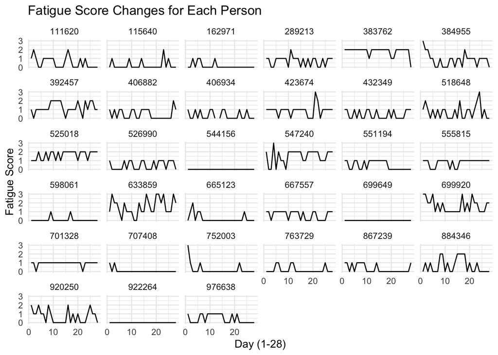

```r
# Create the line plots for each person
ggplot(survey_28, aes(x = day, y = fatig, group = random_id)) +
  geom_line() +
  labs(x = "Day (1-28)", y = "Fatigue Score", color = "Random ID") +
  theme_minimal() +
  facet_wrap(~ random_id, scales = "fixed") +
  ggtitle("Fatigue Score Changes for Each Person")
```

```r
model <- lmer(fatig ~ aub1 + (1 + day | random_id), data = survey_28)
summary(model)
Anova(model, type = 3, test = "F")
```

- aub1_Alcohol use: b=-0.15, F(1,895.85)=5.45, p=0.01972 *
- psb1_Partnered sexual behavior
- osb1_Online sexual behavior
- ssb1_Solo sexual activity
- dub1_Drug use
- bpa_Drinking contexts
- pub1_Pornography

### Anxiety symptoms: Mood + Worry

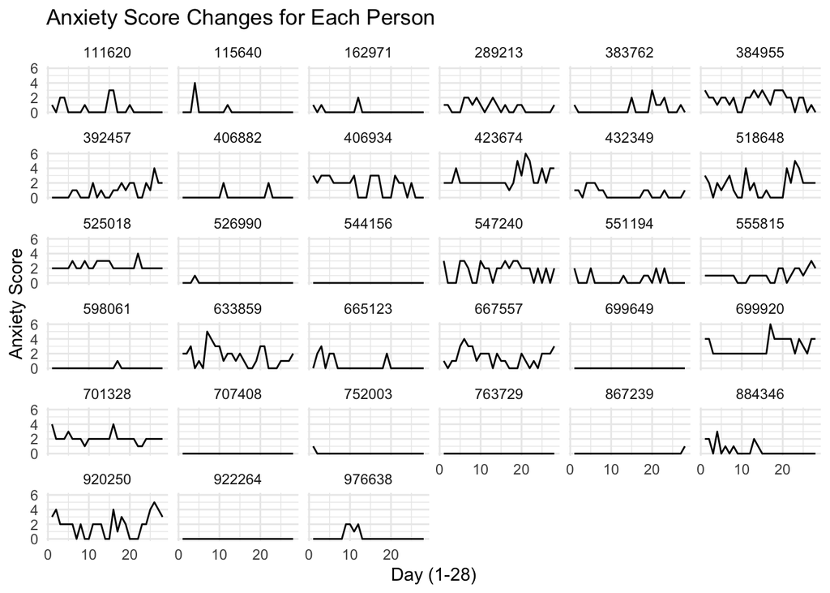

```r
# Create the line plots for each person
ggplot(survey_28, aes(x = day, y = anx_sum, group = random_id)) +
  geom_line() +
  labs(x = "Day (1-28)", y = "Anxiety Score", color = "Random ID") +
  theme_minimal() +
  facet_wrap(~ random_id, scales = "fixed") +
  ggtitle("Anxiety Score Changes for Each Person")
```

```r
glimpse(survey_28)
model <- lmer(anx_sum ~ bpa + (1 + day | random_id), data = survey_28)
summary(model)
Anova(model, type = 3, test = "F")
```

### Posttraumatic stress:

Reexperiencing, Avoidance, Negative cognitions, Hyperarousal

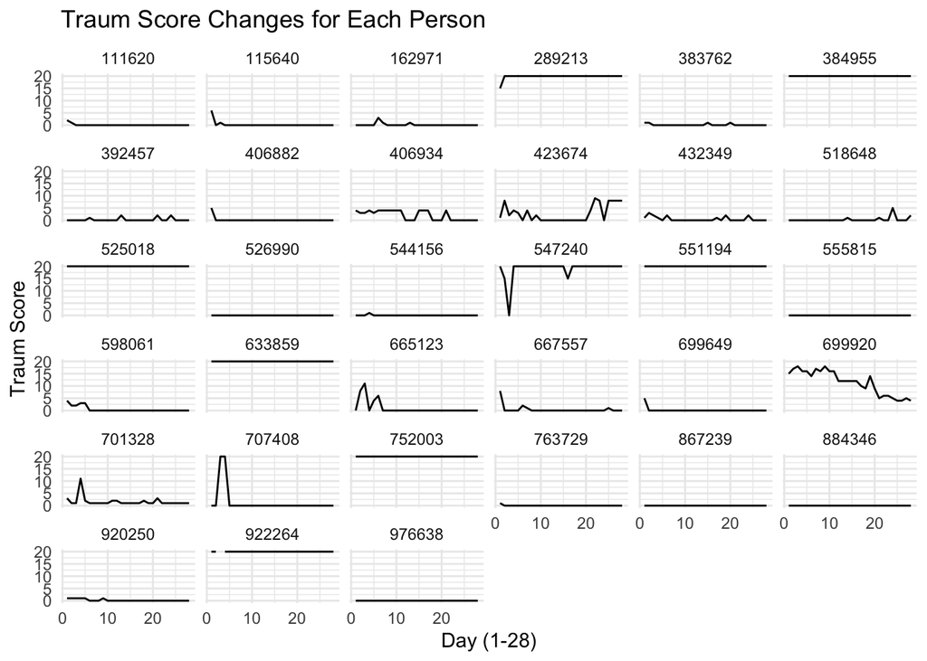

```r
# Create the line plots for each person
ggplot(survey_28, aes(x = day, y = traum_sum, group = random_id)) +
  geom_line() +
  labs(x = "Day (1-28)", y = "Traum Score", color = "Random ID") +
  theme_minimal() +
  facet_wrap(~ random_id, scales = "fixed") +
  ggtitle("Traum Score Changes for Each Person")
```

```r
model <- lmer(traum_sum ~ aub1 * bpa + (1 + day | random_id), data = survey_28)
summary(model)
Anova(model, type = 3, test = "F")
```

- aub1_Alcohol use: b=-0.46, F(1,864.65)=6.78, p=0.0093626 **
- psb1_Partnered sexual behavior
- osb1_Online sexual behavior
- ssb1_Solo sexual activity
- dub1_Drug use
- bpa_Drinking contexts: b=-0.59, F(1,864.66)=7.84, p=0.0052103 **
- pub1_Pornography